# coding_assignment_4

Shehroz Jawad Khan

Assigned November 18, 2021

##### This homework is due by **11:55 pm on Sunday, November 28, 2021**. To complete this assignment, follow these steps:

1. Download the `coding_assignment_4.Rmd` file from LMS.
2. Open `coding_assignment_4.Rmd` in RStudio.
3. Replace the “Your Name Here” text in the `author:` field with your own name.
4. Supply your solutions to the homework by editing `coding_assignment_4.Rmd`.
5. When you have completed the homework and have **checked** that your code both runs in the Console and knits correctly when you click `Knit HTML`, rename the R Markdown file to `coding_assignment_4_YourNameHere.Rmd`, and submit BOTH the markdown and the HTML on LMS (YourNameHere should be changed to your own name.)

##### Homework tips:

1. Recall the following useful RStudio hotkeys.

| Keystroke | Description |
| --- | --- |
| `<tab>` | Autocompletes commands and filenames, and lists arguments for functions. |
| `<up>` | Cycles through previous commands in the console prompt |
| `<ctrl-up>` | Lists history of previous commands matching an unfinished one |
| `<ctrl-enter>` | Runs current line from source window to Console. Good for trying things out ideas from a source file. |
| `<ESC>` | Aborts an unfinished command and get out of the + prompt |

**Note**: Shown above are the Windows/Linux keys. For Mac OS X, the `<ctrl>` key should be substituted with the `<command>` (⌘) key.

2. Instead of sending code line-by-line with `<ctrl-enter>`, you can send entire code chunks, and even run all of the code chunks in your .Rmd file. Look under the menu of the Source panel.
3. Run your code in the Console and Knit HTML frequently to check for errors.
4. You may find it easier to solve a problem by interacting only with the Console at first.

```r
## Load required packages here
library(readr)
library(tidyverse)
library(psych)
library(GGally)
library(dplyr)
library(ggplot2)
library(Rmisc)
library(ggpubr)
```

### Problem 1: 1-sample t-tests

Start by loading the `adult_data` dataset that can be accessed by running the code chunk below. Once the dataset has been loaded run a few exploratory data analysis commands including `View()` to get a feel of the dataset.

```r
## Loading the dataset
adult_data <- read.csv("http://archive.ics.uci.edu/ml/machine-learning-databases/adult/adult.data", header=FALSE,
                       fill=FALSE,
                       strip.white=T,
                       col.names=c("age", "type_employer", "fnlwgt", "education",
                                   "education_num","marital", "occupation", "relationship", "race","sex","capital_gain",
                                   "capital_loss", "hr_per_week","country", "income"))
```

```r
#Viewing the data set
View(adult_data)
```

```r
#Looking at the head of the data set
head(adult_data)
```

```
##   age    type_employer fnlwgt education education_num            marital
## 1  39        State-gov  77516 Bachelors            13      Never-married
## 2  50 Self-emp-not-inc  83311 Bachelors            13 Married-civ-spouse
## 3  38          Private 215646   HS-grad             9           Divorced
## 4  53          Private 234721      11th             7 Married-civ-spouse
## 5  28          Private 338409 Bachelors            13 Married-civ-spouse
## 6  37          Private 284582   Masters            14 Married-civ-spouse
##          occupation  relationship  race    sex capital_gain capital_loss
## 1      Adm-clerical Not-in-family White   Male         2174            0
## 2   Exec-managerial       Husband White   Male            0            0
## 3 Handlers-cleaners Not-in-family White   Male            0            0
## 4 Handlers-cleaners       Husband Black   Male            0            0
## 5    Prof-specialty          Wife Black Female            0            0
## 6   Exec-managerial          Wife White Female            0            0
##   hr_per_week       country income
## 1          40 United-States  <=50K
## 2          13 United-States  <=50K
## 3          40 United-States  <=50K
## 4          40 United-States  <=50K
## 5          40          Cuba  <=50K
## 6          40 United-States  <=50K
```

```r
#looking at the tail of the data set
tail(adult_data)
```

```
##       age type_employer fnlwgt    education education_num            marital
## 32556  22       Private 310152 Some-college            10      Never-married
## 32557  27       Private 257302   Assoc-acdm            12 Married-civ-spouse
## 32558  40       Private 154374      HS-grad             9 Married-civ-spouse
## 32559  58       Private 151910      HS-grad             9            Widowed
## 32560  22       Private 201490      HS-grad             9      Never-married
## 32561  52  Self-emp-inc 287927      HS-grad             9 Married-civ-spouse
##              occupation  relationship  race    sex capital_gain capital_loss
## 32556   Protective-serv Not-in-family White   Male            0            0
## 32557      Tech-support          Wife White Female            0            0
## 32558 Machine-op-inspct       Husband White   Male            0            0
## 32559      Adm-clerical     Unmarried White Female            0            0
## 32560      Adm-clerical     Own-child White   Male            0            0
## 32561   Exec-managerial          Wife White Female        15024            0
##       hr_per_week       country income
## 32556          40 United-States  <=50K
## 32557          38 United-States  <=50K
## 32558          40 United-States   >50K
## 32559          40 United-States  <=50K
## 32560          20 United-States  <=50K
## 32561          40 United-States   >50K
```

```r
#Looking at the structure of the data set
str(adult_data)
```

```
## 'data.frame':    32561 obs. of  15 variables:
##  $ age          : int  39 50 38 53 28 37 49 52 31 42 ...
##  $ type_employer: chr  "State-gov" "Self-emp-not-inc" "Private" "Private" ...
##  $ fnlwgt       : int  77516 83311 215646 234721 338409 284582 160187 209642 45781 159449 ...
##  $ education    : chr  "Bachelors" "Bachelors" "HS-grad" "11th" ...
##  $ education_num: int  13 13 9 7 13 14 5 9 14 13 ...
##  $ marital      : chr  "Never-married" "Married-civ-spouse" "Divorced" "Married-civ-spouse" ...
##  $ occupation   : chr  "Adm-clerical" "Exec-managerial" "Handlers-cleaners" "Handlers-cleaners" ...
##  $ relationship : chr  "Not-in-family" "Husband" "Not-in-family" "Husband" ...
##  $ race         : chr  "White" "White" "White" "Black" ...
##  $ sex          : chr  "Male" "Male" "Male" "Male" ...
##  $ capital_gain : int  2174 0 0 0 0 0 0 0 14084 5178 ...
##  $ capital_loss : int  0 0 0 0 0 0 0 0 0 0 ...
##  $ hr_per_week  : int  40 13 40 40 40 40 16 45 50 40 ...
##  $ country      : chr  "United-States" "United-States" "United-States" "United-States" ...
##  $ income       : chr  "<=50K" "<=50K" "<=50K" "<=50K" ...
```

```r
#looking at the summary statistics of the data set
summary(adult_data)
```

```
##       age        type_employer          fnlwgt         education
##  Min.   :17.00   Length:32561       Min.   :  12285   Length:32561
##  1st Qu.:28.00   Class :character   1st Qu.: 117827   Class :character
##  Median :37.00   Mode  :character   Median : 178356   Mode  :character
##  Mean   :38.58                      Mean   : 189778
##  3rd Qu.:48.00                      3rd Qu.: 237051
##  Max.   :90.00                      Max.   :1484705
##  education_num     marital           occupation        relationship
##  Min.   : 1.00   Length:32561       Length:32561       Length:32561
##  1st Qu.: 9.00   Class :character   Class :character   Class :character
##  Median :10.00   Mode  :character   Mode  :character   Mode  :character
##  Mean   :10.08
##  3rd Qu.:12.00
##  Max.   :16.00
##      race               sex             capital_gain    capital_loss
##  Length:32561       Length:32561       Min.   :    0   Min.   :   0.0
##  Class :character   Class :character   1st Qu.:    0   1st Qu.:   0.0
##  Mode  :character   Mode  :character   Median :    0   Median :   0.0
##                                        Mean   : 1078   Mean   :  87.3
##                                        3rd Qu.:    0   3rd Qu.:   0.0
##                                        Max.   :99999   Max.   :4356.0
##   hr_per_week      country             income
##  Min.   : 1.00   Length:32561       Length:32561
##  1st Qu.:40.00   Class :character   Class :character
##  Median :40.00   Mode  :character   Mode  :character
##  Mean   :40.44
##  3rd Qu.:45.00
##  Max.   :99.00
```

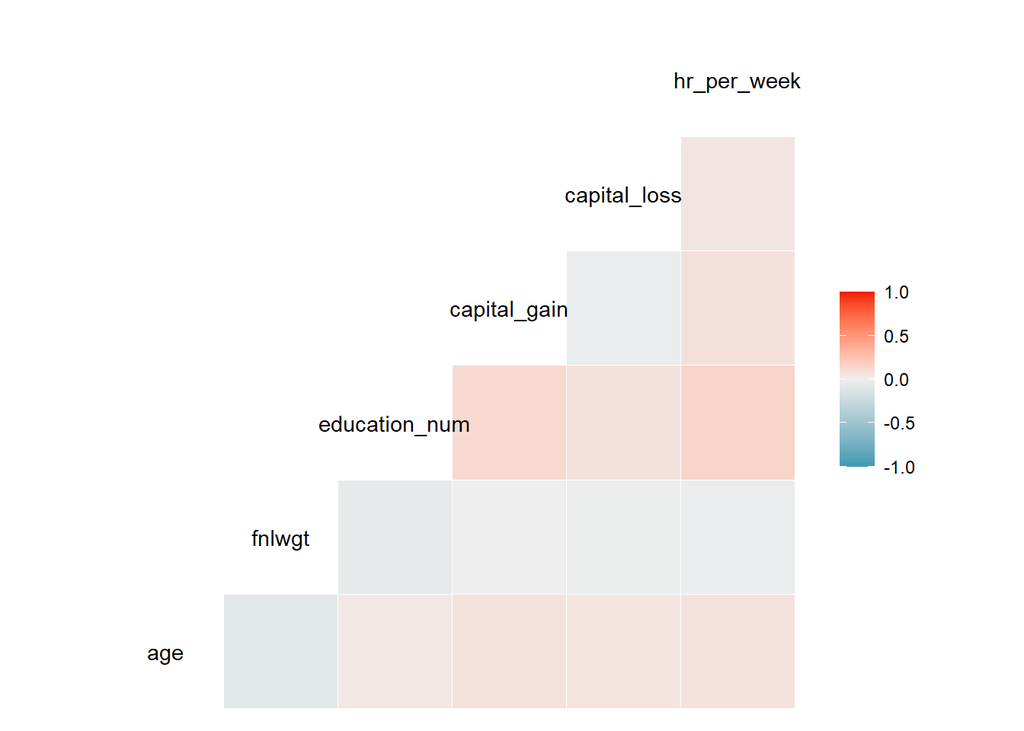

```r
#Looking at the correlations between different numeric variables in the data set
ggcorr(adult_data)
```

#### (a) Using your knowledge of the tidyverse and 1-sample t-testing, construct a table called summary_table1 that shows the average `capital_gain` across `education`, along with the lower and upper endpoints of a 95% confidence interval. Your table should look something like:

```
      education       mean       lower      upper
1          10th   404.5745   91.893307   717.2557
2          11th   215.0979  144.306937   285.8888
3          12th   284.0878  126.824531   441.3510
...
```

```r
# Your code here
table <- adult_data %>%
  group_by(education) %>%
  dplyr::summarise(mean = mean(capital_gain),
            lower = mean - (1.96 * sd(capital_gain) / sqrt(n())),
            upper = mean + (1.96 * sd(capital_gain) / sqrt(n()))
  )

table
```

```
## # A tibble: 16 x 4
##    education      mean   lower  upper
##    <chr>         <dbl>   <dbl>  <dbl>
##  1 10th           405.   92.3    717.
##  2 11th           215.  144.     286.
##  3 12th           284.  127.     441.
##  4 1st-4th        126.    6.53   245.
##  5 5th-6th        176.   75.0    277.
##  6 7th-8th        234.  155.     313.
##  7 9th            342.  -43.2    727.
##  8 Assoc-acdm     640.  410.     871.
##  9 Assoc-voc      715.  523.     907.
## 10 Bachelors     1756. 1509.    2004.
## 11 Doctorate     4770. 3107.    6433.
## 12 HS-grad        577.  481.     672.
## 13 Masters       2563. 2047.    3078.
## 14 Preschool      898. -695.    2492.
## 15 Prof-school  10414. 8206.   12623.
## 16 Some-college   599.  489.     709.
```

#### (b) Sort your table so that it appears in ascending order of education. E.g., Preschool is the lowest, 1st-4th the next lowest, etc. For the post-high school grades, you can use the ordering: Assoc-voc, Assoc-acdm, Some-college, Bachelors, Masters, Prof-school, Doctorate.

```r
# Your code here
ordered_table <- table %>%
    arrange(match(education, c("Preschool", "1st-4th", "5th-6th","7th-8th", "9th", "10th", "11th", "12th", "HS-grad", "Assoc-voc", "Assoc-acdm", "Some-college", "Bachelors", "Masters", "Prof-school", "Doctorate")), desc(mean), desc(lower), desc(upper))
ordered_table
```

```
## # A tibble: 16 x 4
##    education      mean   lower  upper
##    <chr>         <dbl>   <dbl>  <dbl>
##  1 Preschool      898. -695.    2492.
##  2 1st-4th        126.    6.53   245.
##  3 5th-6th        176.   75.0    277.
##  4 7th-8th        234.  155.     313.
##  5 9th            342.  -43.2    727.
##  6 10th           405.   92.3    717.
##  7 11th           215.  144.     286.
##  8 12th           284.  127.     441.
##  9 HS-grad        577.  481.     672.
## 10 Assoc-voc      715.  523.     907.
## 11 Assoc-acdm     640.  410.     871.
## 12 Some-college   599.  489.     709.
## 13 Bachelors     1756. 1509.    2004.
## 14 Masters       2563. 2047.    3078.
## 15 Prof-school  10414. 8206.   12623.
## 16 Doctorate     4770. 3107.    6433.
```

#### (c) What can you conclude about the association between capital gains and education levels? Does there appear to be a statistically significant difference in capital gains across education?

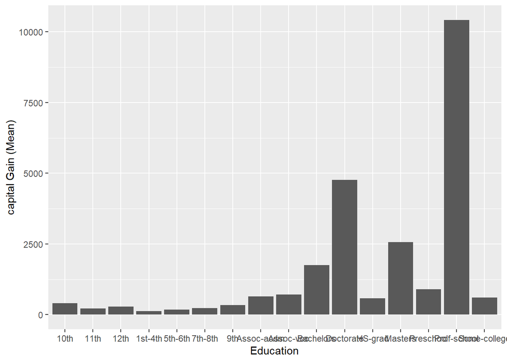

```r
#Using graphical representation to get the gist of the association
ggplot(ordered_table, aes(as.factor(education), mean)) +
    geom_bar(stat = "identity") +
    labs(y = "capital Gain (Mean)", x = "Education");
```

From the ordered table, we can see that there is a positive association between the education levels and capital gains. There appears to statistically significant difference between capital gains across education as the mean capital gains lie inside the 95% confidence intervals.

### Problem 2: Two-sample t-test

#### (a) Using your knowledge of the 2-sample t-testing, test whether women on average work the same number of hours per week as men.

```r
# Your code here
#Saving the data in two different vectors
women_hr_per_week <- adult_data %>%
  filter(sex == "Female") %>%
  pull(hr_per_week)
men_hr_per_week <- adult_data %>%
  filter(sex == "Male") %>%
  pull(hr_per_week)
# Compute t-test
stat <- t.test(women_hr_per_week, men_hr_per_week)
stat
```

```
##
##  Welch Two Sample t-test
##
## data:  women_hr_per_week and men_hr_per_week
## t = -42.882, df = 21958, p-value < 2.2e-16
## alternative hypothesis: true difference in means is not equal to 0
## 95 percent confidence interval:
##  -6.292787 -5.742664
## sample estimates:
## mean of x mean of y
##  36.41036  42.42809
```

#### (b) Use in-line coding to answer the question from part (a). Your answer should include what we expect the average difference in means to be, the confidence interval around the difference in means, and our confidence level.

The average difference in means of hrs per week of both genders is estimated to be 6.0177251. The confidence interval around the difference in means is -6.2927866, -5.7426636. The confidence level is 95%. We expect the difference in means of mens hours per week to be different that women’s hours per week. The estimate is statistically significant at 1% significance level.

#### (c) Based on domain expertise, and on ground knowledge, list potential reasons why women may be working less hours than men?

Based on domain expertise and ground knowledge, I would say that women may be working less hours than men because they allot more time to caregiving and other domestic unpaid activities. Additionally, women are often encouraged to take occupational roles such as going part-time or internally facing roles, while men are retained for more ‘powerful’ positions which demand greater working hours. They may be working shorter hours themselves too the commitment to family is primary by nature according to their respective cultural notions.

#### (d) Using your knowledge of the 2-sample t-testing, test whether women on average have less years of education than men.

```r
# Your code here
#Saving the data in two different vectors
women_education <- adult_data %>%
  filter(sex == "Female") %>%
  pull(education_num)
men_education <- adult_data %>%
  filter(sex == "Male") %>%
  pull(education_num)
# Compute t-test
stat2 <- t.test(women_education, men_education)
stat2
```

```
##
##  Welch Two Sample t-test
##
## data:  women_education and men_education
## t = -2.3015, df = 23730, p-value = 0.02137
## alternative hypothesis: true difference in means is not equal to 0
## 95 percent confidence interval:
##  -0.124333754 -0.009960459
## sample estimates:
## mean of x mean of y
##  10.03574  10.10289
```

#### (e) Using your findings from the above t-test, comment on whether education may be playing a role in why women work less.

We can see that the p-value is less than 0.05, which means that we reject the null and accept the alternative that the true difference in means is not equal to 0. This means that men’s average education is significantly different from women’s average education. This could indeed play a role in less hours of work per week for women as women in the sample could be less qualified for occupational roles which demand more hours of work per week.

### Problem 3: 1- Sample Proportion Testing

#### (a) Create a new variable in `adult_data` called `high_income` that takes the value 1 if individual earns more than 50k, and zero otherwise. Then calculate the mean of this variable. What does variable mean?

```r
# Your code here
adult_data$high_income <- ifelse(adult_data$income == ">50K", 1, 0)
mean_high_income <- mean(adult_data$high_income)
mean_high_income
```

```
## [1] 0.2408096
```

It is a dummy variable. It represents the subgroup of high income earners in our sample.

#### (b) Create a summary table that shows ONLY the counts of women who are high earners and the counts of women who are not high earners, as well as the proportion of women who are high earners.

```r
#Your code here
#Summary table showing the counts of women as high earners and not high earners
women_earners <- adult_data %>%
  filter(sex == "Female") %>%
  summarise(
    women_high_earners = length(which(high_income == 1)),
    women_not_high_earners = length(which(high_income == 0))
  )
women_earners
```

```
##   women_high_earners women_not_high_earners
## 1               1179                   9592
```

```r
#Proportion of women which are high earners
women_high_earner_proportion = (1179/(1179 + 9592))
women_high_earner_proportion
```

```
## [1] 0.1094606
```

#### (c) Use your knowledge of proportion_testing to check whether the proportion of women in the population who are high earners is greater than 10% at the 95% confidence level

```r
#Your code here
prop.test(x = 1179 , n = 1179 + 9592 , p = 0.1, correct = FALSE,
              alternative = "greater")
```

```
##
##  1-sample proportions test without continuity correction
##
## data:  1179 out of 1179 + 9592, null probability 0.1
## X-squared = 10.711, df = 1, p-value = 0.0005324
## alternative hypothesis: true p is greater than 0.1
## 95 percent confidence interval:
##  0.10461 1.00000
## sample estimates:
##         p
## 0.1094606
```

#### (d) What do you conclude from your findings from part (c)?

The p-value is 0.0005324, which is less than 0.05. Hence, we reject the null and accept the alternative that the proportion of females who are high earners is significantly greater than 10%.

### Problem 4: 2-Sample Proportion Testing

In class we only learned how to compute 1 proportion sample tests. This excercise will walk you through how to conduct two sample prop tests. Review the sample code below, and answer the following questions.

```r
It is possible to compute a CI for a difference in two proportions using prop.test with summary information. For example, to find a 95% CI for the difference in proportion Sheffield sites with robin song in 2005 vs 2006, we first examine the data:

table(data$DaySong, data$Year)

##          Year
## DaySong   2005 2006
##   Absent    22   32
##   Present   35   32

To pass this information to prop.test, we now need x to have two entries (the number of “successes” in 2005 and 2006) and n also needs to have two entries (the sample size in each group). We would run:

prop.test(x=c(35,32), n=c(22+35, 32+32),
          conf.level=0.95)
##
##  2-sample test for equality of proportions with continuity
##  correction
##
## data:  c(35, 32) out of c(22 + 35, 32 + 32)
## X-squared = 1.1586, df = 1, p-value = 0.2818
## alternative hypothesis: two.sided
## 95 percent confidence interval:
##  -0.07855448  0.30662466
## sample estimates:
##    prop 1    prop 2
## 0.6140351 0.5000000
```

#### (a) Create a summary table that shows the proportion of men and women who are high earners.

```r
#Your code here
men_earners <- adult_data %>%
  filter(sex == "Male") %>%
  summarise(
    men_high_earners = length(which(high_income == 1)),
    men_not_high_earners = length(which(high_income == 0))
  )
men_earners
```

```
##   men_high_earners men_not_high_earners
## 1             6662                15128
```

```r
##Proportion of men which are high earners
men_high_earner_proportion = (6662/(6662 + 15128))
men_high_earner_proportion
```

```
## [1] 0.3057366
```

```r
#Creating the summary table
table(men_high_earner_proportion, women_high_earner_proportion)
```

```
##                           women_high_earner_proportion
## men_high_earner_proportion 0.109460588617584
##          0.305736576411198                 1
```

#### (b) Conduct a proportion test to evaluate whether the proportion of female high earners in the population is less than the proportion of male high earners.

```r
#Your code here
prop.test(x=c(1179,6662), n=c(10771, 21790),
          conf.level=0.95, alternative = "less")
```

```
##
##  2-sample test for equality of proportions with continuity correction
##
## data:  c(1179, 6662) out of c(10771, 21790)
## X-squared = 1517.8, df = 1, p-value < 2.2e-16
## alternative hypothesis: less
## 95 percent confidence interval:
##  -1.0000000 -0.1890763
## sample estimates:
##    prop 1    prop 2
## 0.1094606 0.3057366
```

#### (c) What do you conclude about the proportion of male high earners vs the proportion of female high earners.

The p-value is 2.2e-16, which is less than 0.05. Hence, we reject the null and accept the alternative that proportion of female high earners in the population is less than the proportion of male high earners in the population.

### Problem 5: Quick Plots in R with GGplot2

#### (a) Create a histogram of age from our adult dataset.Use your histogram of age to answer whether the distribution of age in our dataset is skewed to the right or to the left.

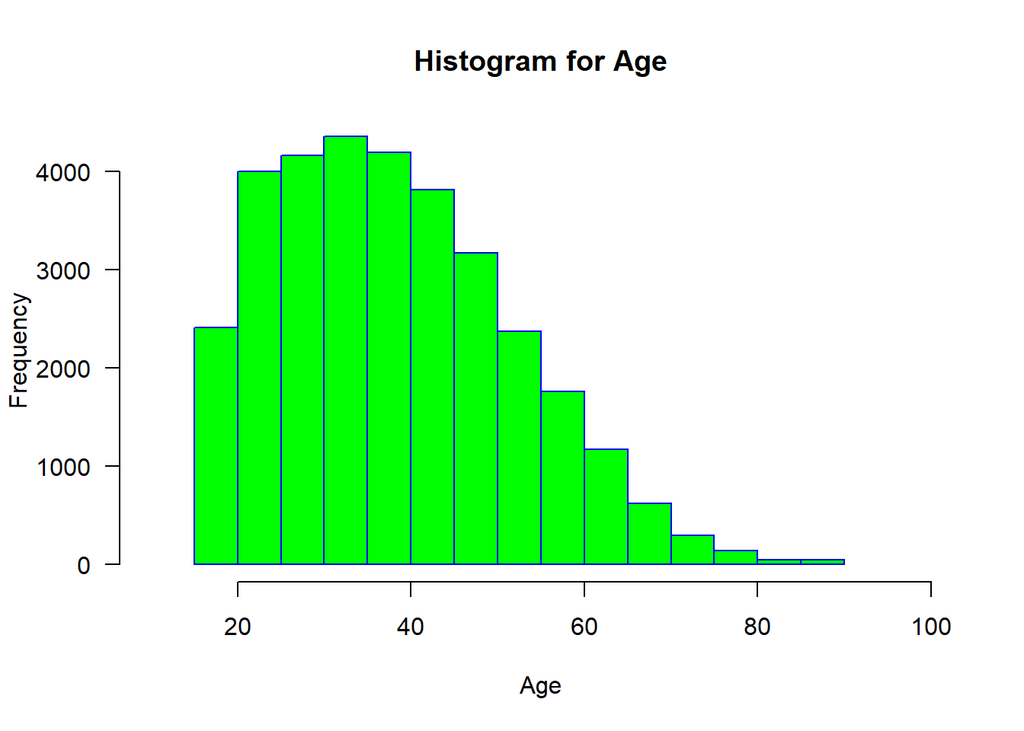

```r
#Your code here
hist(adult_data$age,
     main="Histogram for Age",
     xlab="Age",
     border="blue",
     col="green",
     xlim=c(10, 100),
     las=1,
     breaks=20)
```

The distribution of age in our data is skewed to the right.

#### (b) Create a boxplot of years of education by age for each sex. The box plot for each sex should have a different color. Does our data contain more outliers for men or women?

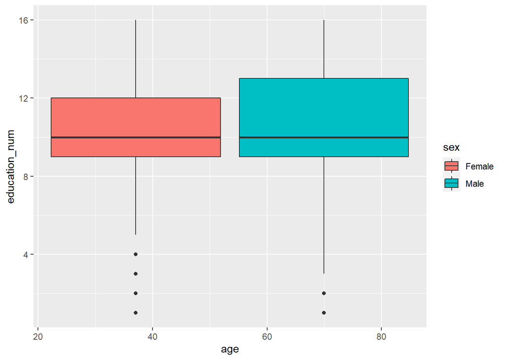

```r
#Your code here
ggplot(adult_data, aes(x=age, y=education_num, fill=sex)) +
    geom_boxplot()
```

Our data has more outliers for females.

#### (c) Create a visualization that shows the count of the number of times each race appears in our data

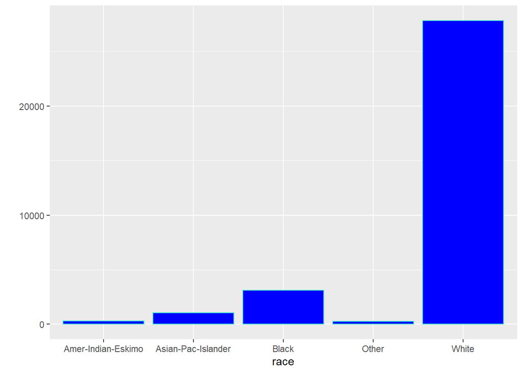

```r
#Your code here
qplot(race,
      data = adult_data,
      geom = "bar",
      fill = I("blue"),
      color = I("turquoise"))
```

#### (d) Write a loop that prints a visualization for each column in adult_data. The visualization should be a histogram if the variable is numeric, and a barchart if the variable is not numeric. Each visualization should be titled by the name of the variable it is visualizing.

```r
# Your code here
for(i in names(adult_data)){
ifelse(is.numeric(i) == TRUE, hist(adult_data[,i]), qplot(i, data = adult_data, geom = "bar"))
}
```

[output not shown]